# EntregaNoteboookTFMcorregido

Importación de librerías Para comenzar con la revisión de los datos, se procede a importar librerías especializadas de Python que permiten abordar cada una de las fases del análisis de datos: desde la manipulación y transformación de la información hasta la representación gráfica de los resultados. Pandas y NumPy proporcionan un entorno robusto para el procesamiento eficiente de registros, mientras que Matplotlib, Seaborn y Plotly permiten convertir grandes volúmenes de datos en representaciones visuales fáciles de interpretar. Esta combinación facilita detectar patrones, tendencias y anomalías que podrían pasar desapercibidas mediante una revisión únicamente tabular.Aunque esta etapa no genera resultados estadísticos, nos permite establecer la infraestructura analítica necesaria para desarrollar un estudio escalable y real.

```python
# Librerías utilizadas en el notebook
import numpy as np
import pandas as pd
import matplotlib.pyplot as plt
import seaborn as sns
from pathlib import Path

pd.set_option('display.max_columns', 100)
pd.set_option('display.width', 200)
print("Librerías importadas OK ✅")
```

```
Librerías importadas OK ✅
```

Una vez preparado el entorno de trabajo, hacemos la carga de la base de datos correspondiente a la cartera de clientes del Banco Sabadell. El conjunto de datos representa el comportamiento financiero de aproximadamente 10.000 de clientes El tamaño de la muestra permite realizar segmentaciones por grupos de edad, patrimonio, antigüedad y contratación de productos sin perder significancia estadística, lo cual incrementa la confiabilidad de los resultados obtenidos posteriormente. Antes de realizar cualquier proceso de limpieza o modelado resulta imprescindible conocer la estructura de la información disponible. Para ello se investigaron las primeras filas del dataset y lacomposición de las variables. Este procedimiento permite comprender cómo se encuentra organizada la información y detectar posibles inconsistencias desde una perspectiva preliminar.

```python
input_dir = Path.cwd() / "input"
xlsx_files = []
if input_dir.exists():
    xlsx_files = sorted(input_dir.glob("*.xlsx"))
else:
    xlsx_files = sorted(Path.cwd().glob("*.xlsx"))

if not xlsx_files:
    raise FileNotFoundError(
        f"No se encontró ningún archivo .xlsx en {input_dir} ni en el directorio actual."
    )

excel_path = xlsx_files[0]
df_datasabadell = pd.read_excel(excel_path, engine="openpyxl")
print(f"Listo✅! Excel cargado desde: {excel_path}")
print(f"output_dir será: {Path.cwd() / 'output'}")
```

```
Listo✅! Excel cargado desde: c:\Users\jmendozarojas\OneDrive - Getronics\Escritorio\INESDI\TFM\Entrega 2\BD_Sabadell.xlsx
output_dir será: c:\Users\jmendozarojas\OneDrive - Getronics\Escritorio\INESDI\TFM\Entrega 2\output
```

El siguiente análisis es para revisar medidas estadísticas descriptivas para así resumir miles de registros en indicadores fácilmente interpretables.

```python
# Estadística descriptiva de las variables clave de perfil / consumo
vars_clave = ['antig','edad','totalpasta','renta_final','gastos_tot','nivren',
              'margecomercialut','credit','revolving','tothipo','nominaimp','rdom','tpv']
df_datasabadell[vars_clave].describe().T
```

|  | count | mean | std | min | 25% | 50% | 75% | max |
| --- | --- | --- | --- | --- | --- | --- | --- | --- |
| antig | 10000.0 | 218.333500 | 795.911927 | 1.00 | 47.000000 | 121.000 | 233.000000 | 9999.00 |
| edad | 10000.0 | 49.354400 | 20.248531 | 0.00 | 36.000000 | 49.000 | 64.000000 | 116.00 |
| totalpasta | 10000.0 | 23847.890669 | 86505.052000 | 0.00 | 287.467500 | 2123.225 | 17078.425000 | 4798534.49 |
| renta_final | 7239.0 | 25369.533403 | 81677.699690 | 4367.76 | 12310.628077 | 16479.540 | 25385.683636 | 4496606.59 |
| nivren | 10000.0 | 1.933000 | 0.937869 | 0.00 | 1.000000 | 2.000 | 3.000000 | 5.00 |
| margecomercialut | 10000.0 | 128.151498 | 462.907653 | -1961.80 | 6.077500 | 36.050 | 138.195000 | 31639.73 |
| credit | 10000.0 | 100.536738 | 2457.438350 | 0.00 | 0.000000 | 0.000 | 0.000000 | 134200.66 |
| revolving | 10000.0 | 53.858220 | 332.113919 | 0.00 | 0.000000 | 0.000 | 0.000000 | 7901.99 |
| tothipo | 10000.0 | 13616.248837 | 52116.240914 | 0.00 | 0.000000 | 0.000 | 0.000000 | 2538920.97 |
| nominaimp | 10000.0 | 1141.936248 | 4359.877628 | 0.00 | 0.000000 | 0.000 | 0.000000 | 335186.92 |
| rdom | 10000.0 | 8.978100 | 11.710924 | 0.00 | 0.000000 | 5.000 | 14.000000 | 86.00 |
| tpv | 10000.0 | 0.000700 | 0.026450 | 0.00 | 0.000000 | 0.000 | 0.000000 | 1.00 |

Se observó que algunas variables presentan una elevada dispersión, indicando que la cartera de clientes está compuesta por perfiles financieros muy heterogéneos. Esta diversidad evidencia la necesidad de implementar estrategias de segmentación comercial en lugar de campañas masivas dirigidas a todos los clientes por igual, ya que tenemos diferentes formas de actuar y de gestionar el dinero por parte de grupos de clientes y segmentos.

Cálculo del número total de clientes: Se contabilizó el número total de clientes presentes en la base de datos con el objetivo de establecer una referencia que permitiera verificar el impacto de las diferentes fases de limpieza y transformación. Este indicador constituye un punto de control dentro del proyecto. Conocer el tamaño inicial de la muestra facilita comprobar posteriormente que las operaciones de depuración únicamente eliminan registros realmente inconsistentes y no reducen innecesariamente la representatividad del conjunto de datos.

```python
#Función para contar la cantidad total de clientes en la BD
total_clientes=df_datasabadell.id_cliente.count()
print(f"El total de clientes registrados en la BD es : {total_clientes}")
```

```
El total de clientes registrados en la BD es : 10000
```

Perfilado estadístico y análisis inicial de calidad Se realizó un perfilado estadístico de las variables para identificar rangos, valores mínimos y máximos, posibles inconsistencias y comportamientos poco habituales. Durante esta revisión se identificaron varios aspectos relevantes: • clientes con edad igual a cero, correspondientes a cuentas infantiles; • clientes sin productos contratados; • registros sin patrimonio asociado; • variables con valores nulos significativos. En lugar de asumir automáticamente que estos registros eran erróneos, se analizaron desde la perspectiva del negocio bancario. Este enfoque evita eliminar datos válidos y mejora considerablemente la calidad del análisis posterior.

```python
# Análisis:
# Edad =0.000000 corresponde a padres que crean una cuenta de ahorro para sus hijos
# totalpasta =0.000000 corresponde a los cliente que no tiene fondos.
# impoped   = 0.000000 corresponde a los clientes que no tuvieron egresos en su cuenta
resumen = df_datasabadell.describe()
print(resumen)
```

```
        id_cliente         antig          edad    totalpasta       impoped       impopeh  ind_cuentaexpansion  ind_cuentaexpansionnegocios  ind_cuentaexpansionpremium  ind_cuentaexperiencia  \
count  10000.00000  10000.000000  10000.000000  1.000000e+04  1.000000e+04  1.000000e+04         10000.000000                 10000.000000                10000.000000           10000.000000
mean    5000.50000    218.333500     49.354400  2.384789e+04  4.945997e+03  5.433100e+03             0.347200                     0.007000                    0.022800               0.080400
std     2886.89568    795.911927     20.248531  8.650505e+04  2.296940e+04  2.168653e+04             0.476104                     0.083377                    0.149273               0.271925
min        1.00000      1.000000      0.000000  0.000000e+00  0.000000e+00  0.000000e+00             0.000000                     0.000000                    0.000000               0.000000
25%     2500.75000     47.000000     36.000000  2.874675e+02  7.624000e+01  4.888250e+01             0.000000                     0.000000                    0.000000               0.000000
50%     5000.50000    121.000000     49.000000  2.123225e+03  1.690965e+03  2.414000e+03             0.000000                     0.000000                    0.000000               0.000000
75%     7500.25000    233.000000     64.000000  1.707842e+04  4.574812e+03  5.740130e+03             1.000000                     0.000000                    0.000000               0.000000
max    10000.00000   9999.000000    116.000000  4.798534e+06  1.055250e+06  1.064506e+06             1.000000                     1.000000                    1.000000               1.000000

       ind_cuentaprimera  ind_cuentaproyeccion  ind_cvautonomos  ind_cvdirect   ind_cvhabit    ind_cvjove  ind_cvjunior    ind_cvmas  ind_cvprestige  ind_cvsenior  ind_estalinv   ind_estalvi  \
count       10000.000000          10000.000000      10000.00000  10000.000000  10000.000000  10000.000000  10000.000000  10000.00000    10000.000000  10000.000000  10000.000000  10000.000000
mean            0.054100              0.066000          0.00110      0.013800      0.000200      0.066000      0.054100      0.00350        0.035500      0.008000      0.334300      0.306700
std             0.226226              0.248295          0.03315      0.116666      0.014141      0.248295      0.226226      0.05906        0.185049      0.089089      0.471769      0.461147
min             0.000000              0.000000          0.00000      0.000000      0.000000      0.000000      0.000000      0.00000        0.000000      0.000000      0.000000      0.000000
25%             0.000000              0.000000          0.00000      0.000000      0.000000      0.000000      0.000000      0.00000        0.000000      0.000000      0.000000      0.000000
50%             0.000000              0.000000          0.00000      0.000000      0.000000      0.000000      0.000000      0.00000        0.000000      0.000000      0.000000      0.000000
75%             0.000000              0.000000          0.00000      0.000000      0.000000      0.000000      0.000000      0.00000        0.000000      0.000000      1.000000      1.000000
max             1.000000              1.000000          1.00000      1.000000      1.000000      1.000000      1.000000      1.00000        1.000000      1.000000      1.000000      1.000000

       ind_altrescc  ind_asvidaestgarcol  ind_asvidaestulinkc  ind_bonsestruc     ind_cialp     ind_credf     ind_credv   ind_diposit        ind_fi  ind_fialtent  ind_gcfisbp   ind_gransel  \
count  10000.000000              10000.0              10000.0      10000.0000  10000.000000  10000.000000  10000.000000  10000.000000  10000.000000  10000.000000      10000.0  10000.000000
mean       0.004600                  0.0                  0.0          0.0001      0.097500      0.002600      0.004200      0.137900      0.056800      0.003200          0.0      0.005300
std        0.067671                  0.0                  0.0          0.0100      0.296652      0.050926      0.064674      0.344812      0.231472      0.056481          0.0      0.072612
min        0.000000                  0.0                  0.0          0.0000      0.000000      0.000000      0.000000      0.000000      0.000000      0.000000          0.0      0.000000
25%        0.000000                  0.0                  0.0          0.0000      0.000000      0.000000      0.000000      0.000000      0.000000      0.000000          0.0      0.000000
```

[output cut: 43 more lines]

```python
# Panorama general: tipos de dato y nulos
resumen = pd.DataFrame({
    'dtype': df_datasabadell.dtypes,
    'nulos': df_datasabadell.isna().sum(),
    '%_nulos': (df_datasabadell.isna().mean()*100).round(1)
}).sort_values('%_nulos', ascending=False)
resumen.head(20)
```

|  | dtype | nulos | %_nulos |
| --- | --- | --- | --- |
| jubilados | float64 | 4966 | 49.7 |
| entre18_45 | float64 | 4966 | 49.7 |
| entre46_65 | float64 | 4966 | 49.7 |
| tipofamilia | str | 4966 | 49.7 |
| menores18 | float64 | 4966 | 49.7 |
| miembrosfamilia | float64 | 4966 | 49.7 |
| renta_final | float64 | 2761 | 27.6 |
| sio_mediospago | float64 | 114 | 1.1 |
| sio_transaccionalidad | float64 | 114 | 1.1 |
| sio_ahorro | float64 | 114 | 1.1 |
| sio_accionabilidad | float64 | 114 | 1.1 |
| sio_aldia | float64 | 114 | 1.1 |
| sio_financiacion | float64 | 114 | 1.1 |
| sio_desvinculacion | float64 | 114 | 1.1 |
| sio_captacion | float64 | 114 | 1.1 |
| sio_vinculacion | float64 | 114 | 1.1 |
| sio_noaccionable | float64 | 114 | 1.1 |
| fase | float64 | 114 | 1.1 |
| sio_proteccion | float64 | 114 | 1.1 |
| ind_cvprestige | int64 | 0 | 0.0 |

Del análisis de la base de datos se desprende que:

- **Variables demográficas (49,7 % nulos, 4.966 registros).** `jubilados`, `entre18_45`, `entre46_65`, `tipofamilia`, `menores18` y `miembrosfamilia` comparten exactamente la misma cifra de omisiones. El patrón confirma que la ausencia se origina en la fuente primaria (falta sistemática de información familiar para casi la mitad de los clientes) y no son huecos aislados. No se imputan: se conserva el nulo y en el modelo del DWH se añade el indicador `tiene_datos_familia` para poder filtrar.
- **`renta_final` (27,6 % nulos).** Los nulos siguen un patrón real: los clientes sin `renta_final` son más jóvenes (41,9 vs 52,2 años) y menos vinculados (0,24 vs 0,42). La ausencia del dato es en sí misma informativa (probablemente clientes jóvenes o nuevos sin cruce fiscal). Por eso no se elimina la columna: **primero se crea el flag `renta_imputada`** para no perder esa señal y después se imputa la mediana por `nivren` (que solo correlaciona 0,09 con `renta_final`, así que no es redundante).
- **Campos `sio_*` y `fase` (1,1 % nulos, 114 filas).** Se eliminan esas 114 **filas**, porque no tienen ninguna puntuación SIO. `fase` se imputa con la mediana.

```python
# 1) Filas sin puntuación SIO: se eliminan (114 registros, 1,1 %)
cols_sio = [
    'sio_vinculacion', 'sio_desvinculacion', 'sio_ahorro', 'sio_aldia',
    'sio_captacion', 'sio_financiacion', 'sio_mediospago',
    'sio_transaccionalidad', 'sio_proteccion', 'sio_noaccionable', 'sio_accionabilidad'
]
filas_antes = len(df_datasabadell)
df_datasabadell = df_datasabadell.dropna(subset=cols_sio).copy()
print(f"Filas eliminadas por SIO nulo: {filas_antes - len(df_datasabadell)}")

# 2) 'fase': imputación por mediana
df_datasabadell['fase'] = df_datasabadell['fase'].fillna(df_datasabadell['fase'].median())

# 3) 'renta_final': primero se guarda el flag "sin dato" y después se imputa la mediana por nivren
df_datasabadell['renta_imputada'] = df_datasabadell['renta_final'].isna().astype(int)
df_datasabadell['renta_final'] = (
    df_datasabadell.groupby('nivren')['renta_final']
    .transform(lambda x: x.fillna(x.median()))
)
print(f"Clientes con renta imputada (flag renta_imputada = 1): {df_datasabadell['renta_imputada'].sum()}")
```

```
Filas eliminadas por SIO nulo: 114
Clientes con renta imputada (flag renta_imputada = 1): 2757
```

Se comprube a eliminación de los valores nulos y el tratamiento de los datos

```python
resumen = pd.DataFrame({
    'dtype': df_datasabadell.dtypes,
    'nulos': df_datasabadell.isna().sum(),
    '%_nulos': (df_datasabadell.isna().mean()*100).round(1)
}).sort_values('%_nulos', ascending=False)
resumen.head(20)
```

|  | dtype | nulos | %_nulos |
| --- | --- | --- | --- |
| miembrosfamilia | float64 | 4920 | 49.8 |
| tipofamilia | str | 4920 | 49.8 |
| entre46_65 | float64 | 4920 | 49.8 |
| jubilados | float64 | 4920 | 49.8 |
| menores18 | float64 | 4920 | 49.8 |
| entre18_45 | float64 | 4920 | 49.8 |
| impoped | float64 | 0 | 0.0 |
| impopeh | float64 | 0 | 0.0 |
| ind_cuentaexpansionpremium | int64 | 0 | 0.0 |
| ind_cuentaexperiencia | int64 | 0 | 0.0 |
| ind_cuentaprimera | int64 | 0 | 0.0 |
| ind_cuentaproyeccion | int64 | 0 | 0.0 |
| ind_cvautonomos | int64 | 0 | 0.0 |
| ind_cvdirect | int64 | 0 | 0.0 |
| ind_cuentaexpansion | int64 | 0 | 0.0 |
| ind_cuentaexpansionnegocios | int64 | 0 | 0.0 |
| id_cliente | int64 | 0 | 0.0 |
| antig | int64 | 0 | 0.0 |
| edad | int64 | 0 | 0.0 |
| totalpasta | float64 | 0 | 0.0 |

```python
#Analisis de los datos atipicos, conteno e identificación
cantidad_9999 = (df_datasabadell['antig'] == 9999).sum()
print(f"Cantidad de registros con antig == '9999, posibles datos atipicos': {cantidad_9999}")
```

```
Cantidad de registros con antig == '9999, posibles datos atipicos': 64
```

```python
#Se tomo la decisión de eliminar los 64 registros con esos valores antig=9999, de acuerdo al analisis realizado eran clientes que no forman parte del Banco
df_delete = df_datasabadell[df_datasabadell['antig'] == 9999].copy()
print(f"CORRECCIÓN: Registros con antig == 9999 (para eliminar): {len(df_delete)}")
```

```
CORRECCIÓN: Registros con antig == 9999 (para eliminar): 64
```

```python
# Para eliminar realmente del DataFrame principal
df_datasabadell = df_datasabadell[df_datasabadell['antig'] != 9999]

print("\nEliminados los registros con valores 9999")
```

```
Eliminados los registros con valores 9999
```

```python
# Validamos la eliminación de los datos atípicos: 10.000 - 114 (SIO nulos) - 64 (antig = 9999) = 9.822 clientes
total_clientes = df_datasabadell.id_cliente.count()
print(f"El total de clientes registrados en la BD es : {total_clientes}")
```

```
El total de clientes registrados en la BD es : 9822
```

Se construyen las variables que soportan los objetivos 2 y 3:

- **Grupos de productos**: cuentas (`ind_cuenta*`), tarjetas (`ind_cv*`), inversión/ahorro, financiación y otros. El catálogo completo de los 45 indicadores está en `CATALOGO_PRODUCTOS` (más abajo).
- **`tipo_inversion`**: perfil de inversión del cliente (Juvenil ≤ 18 años, Conservador 19–30 años, Pensionado > 30 años), construido a partir de la **edad**.
- **`segmento_edad`**: Joven / Adulto / Senior.
- **`num_prod_inversion`**: nº de productos de **inversión/ahorro** que tiene el cliente (solo la categoría Inversion_Ahorro, no cuentas, tarjetas ni préstamos). Se excluye `ind_estalinv`, que en la fuente es un indicador resumen (vale 1 si el cliente tiene cualquier producto de ahorro/inversión).
- **`tiene_inversion`**: 1 si el cliente tiene al menos un producto de inversión/ahorro.
- **`total_productos_activos`**: nº total de productos del cliente (los 45 indicadores).
- `gastos_tot` llega como texto con formato moneda (" € 1,278.64", " € - "); se convierte a numérico en la preparación para la ingesta en MySQL.

```python
# Función para calcular tipo de inversión según edad
def calcular_tipo_inversion(edad):
    """Calcular tipo de inversión según edad"""
    try:
        edad_val = float(edad)
        if edad_val <= 18:
            return 'Inversión Perfil Juvenil'
        elif edad_val <= 30:
            return 'Inversión Perfil Conservador'
        else:
            return 'Inversión Perfil Pensionado'
    except:
        return 'Inversión Perfil Conservador'  # Valor por defecto

# Calcular tipo de inversión para todos los clientes
df_datasabadell['tipo_inversion'] = df_datasabadell['edad'].apply(calcular_tipo_inversion)

# Mostrar estadísticas de distribución
print("Distribución de tipos de inversión:")
distribucion = df_datasabadell['tipo_inversion'].value_counts()
for tipo, count in distribucion.items():
    porcentaje = (count / len(df_datasabadell)) * 100
    print(f"  - {tipo}: {count} clientes ({porcentaje:.1f}%)")
```

```
Distribución de tipos de inversión:
  - Inversión Perfil Pensionado: 8034 clientes (81.8%)
  - Inversión Perfil Conservador: 1014 clientes (10.3%)
  - Inversión Perfil Juvenil: 774 clientes (7.9%)
```

```python
nulos_restantes = df_datasabadell.isna().sum()
nulos_restantes = nulos_restantes[nulos_restantes > 0]

print(f"\nFilas finales: {len(df_datasabadell)} | Columnas finales: {df_datasabadell.shape[1]}")
if nulos_restantes.empty:
    print("✅ No quedan valores nulos en el dataset.")
else:
    print("⚠️ Columnas con nulos restantes:")
    print(nulos_restantes)
```

```
Filas finales: 9822 | Columnas finales: 85
⚠️ Columnas con nulos restantes:
miembrosfamilia    4890
menores18          4890
entre18_45         4890
entre46_65         4890
jubilados          4890
tipofamilia        4890
dtype: int64
```

```python
#Segementacion de clientes por tipo de cuenta
# Lista de columnas a seleccionar
columnas_seleccion = [
    'id_cliente',
    'ind_cuentaexpansion',
    'ind_cuentaexpansionnegocios',
    'ind_cuentaexpansionpremium',
    'ind_cuentaexperiencia',
    'ind_cuentaprimera',
    'ind_cuentaproyeccion',
    'ind_cvautonomos',
    'ind_cvdirect',
    'ind_cvhabit',
    'ind_cvjove',
    'ind_cvjunior',
    'ind_cvmas',
    'ind_cvprestige',
    'ind_cvsenior',
    'ind_estalinv',
    'ind_estalvi',

]

# Seleccionar las columnas (syntax correcta)
df_tipocuenta = df_datasabadell[columnas_seleccion].copy()
```

```python
# Función para realizar group by por tipo de cuenta y contar cuántas personas tienen ese tipo de cuenta (sumar cuando el tipo de cuenta sea igual a 1)
def group_by_tipo_cuenta(df_datasabadell, account_columns):

    # Verificar que las columnas existan en el DataFrame
    missing_columns = [col for col in account_columns if col not in df_datasabadell.columns]
    if missing_columns:
        print(f"Advertencia: Las siguientes columnas no existen en el DataFrame: {missing_columns}")
        # Remover columnas faltantes de la lista
        account_columns = [col for col in account_columns if col not in missing_columns]

    # Crear un DataFrame para almacenar los resultados
    results = []

    for account_type in account_columns:
        # Contar cuántas personas tienen esta cuenta (valor = 1)
        count = df_datasabadell[df_datasabadell[account_type] == 1][account_type].count()

        # Calcular porcentaje del total
        total_clients = df_datasabadell['id_cliente'].nunique()  # Usar nunique para contar clientes únicos
        percentage = (count / total_clients) * 100 if total_clients > 0 else 0

        results.append({
            'Tipo de Cuenta': account_type,
            'Cantidad': count,
            'Porcentaje': f"{percentage:.2f}%"
        })

    # Crear DataFrame de resultados
    results_df_datasabadell = pd.DataFrame(results)

    # Ordenar por cantidad de personas de mayor a menor
    results_df_datasabadell = results_df_datasabadell.sort_values(by='Cantidad', ascending=False)

    return results_df_datasabadell

columnas_cuenta = [
    'ind_cuentaexpansion',
    'ind_cuentaexpansionnegocios',
    'ind_cuentaexpansionpremium',
    'ind_cuentaexperiencia',
    'ind_cuentaprimera',
    'ind_cuentaproyeccion',
    'ind_cvautonomos',
    'ind_cvdirect',
    'ind_cvhabit',
    'ind_cvjove',
    'ind_cvjunior',
    'ind_cvmas',
    'ind_cvprestige',
    'ind_cvsenior',
    'ind_estalinv',
    'ind_estalvi',

]
```

```python
# Usar la función con df_datasabadell en lugar de df_tipocuenta
# IMPORTANTE: Primero el DataFrame, luego las columnas
resultados = group_by_tipo_cuenta(df_datasabadell, columnas_cuenta)
print(resultados)
```

```
                 Tipo de Cuenta  Cantidad Porcentaje
0           ind_cuentaexpansion      3427     34.89%
14                 ind_estalinv      3261     33.20%
15                  ind_estalvi      2994     30.48%
3         ind_cuentaexperiencia       800      8.14%
5          ind_cuentaproyeccion       657      6.69%
9                    ind_cvjove       657      6.69%
10                 ind_cvjunior       537      5.47%
4             ind_cuentaprimera       537      5.47%
12               ind_cvprestige       355      3.61%
2    ind_cuentaexpansionpremium       226      2.30%
7                  ind_cvdirect       138      1.41%
13                 ind_cvsenior        79      0.80%
1   ind_cuentaexpansionnegocios        70      0.71%
11                    ind_cvmas        34      0.35%
6               ind_cvautonomos        11      0.11%
8                   ind_cvhabit         2      0.02%
```

```python
#Se calcula el promedio de antiguedad del cliente, coincide con el POWER BI
promedio_antiguedad = (df_datasabadell['antig'].mean())
print(f"El promedio de antiguedad de los clientes es: {promedio_antiguedad}")
```

```
El promedio de antiguedad de los clientes es: 154.31948686621868
```

```python
#Se calcula el min de antiguedad del cliente coincide con el POWER BI
minimo_antiguedad = (df_datasabadell['antig'].min())
print(f"El Minimo de antiguedad de la BD de clientes es de: {minimo_antiguedad}")
```

```
El Minimo de antiguedad de la BD de clientes es de: 1
```

```python
# Contar cuántos clientes tienen cada indicador activo
conteo_indicadores = {}  # <- DEFINIR EL DICCIONARIO PRIMERO

for col in columnas_seleccion:
    if col != 'id_cliente' and col in df_tipocuenta.columns:
        # Asumiendo que los indicadores son binarios (0/1 o True/False)
        conteo = df_tipocuenta[col].sum() if df_tipocuenta[col].dtype in [int, float, bool] else len(df_tipocuenta[df_tipocuenta[col] == True])
        conteo_indicadores[col] = conteo  # <- Ahora sí está definido
print(conteo_indicadores)  # Mostrar todos los conteos, no solo el último
```

```
{'ind_cuentaexpansion': np.int64(3427), 'ind_cuentaexpansionnegocios': np.int64(70), 'ind_cuentaexpansionpremium': np.int64(226), 'ind_cuentaexperiencia': np.int64(800), 'ind_cuentaprimera': np.int64(537), 'ind_cuentaproyeccion': np.int64(657), 'ind_cvautonomos': np.int64(11), 'ind_cvdirect': np.int…
```

De acuerdo al analisis se determina los 10 tipos de cuentas con mayor clientes son:

La Concentración Masiva: Existe una fuerte concentración de clientes en los primeros tres productos financieros:

ind_cuentaexpansion: Es el tipo de cuenta líder, rozando los 3,500 clientes.

ind_estalvi: Ocupa el tercer puesto de la tipo de inversión principal con aproximadamente 3,000 clientes.

Caída Pronunciada (Efecto "Larga Cola"): A partir de la cuarta posición (ind_cuentaexperiencia), el volumen cae drásticamente por debajo de los 1,000 clientes (alrededor de 800), lo que representa una reducción de más del 70% en comparación con las cuentas top.

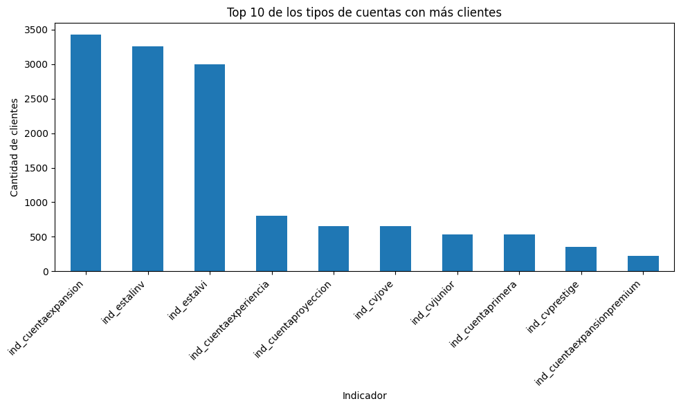

```python
# Crear gráfico (funcionará ahora que conteo_indicadores está definido)
pd.Series(conteo_indicadores).sort_values(ascending=False).head(10).plot(
    kind='bar',
    title='Top 10 de los tipos de cuentas con más clientes',
    figsize=(10, 6)
)
plt.xlabel('Indicador')
plt.ylabel('Cantidad de clientes')
plt.xticks(rotation=45, ha='right')
plt.tight_layout()
plt.show()
```

Pico en la Madurez (40–70 años): La mayor densidad de clientes y los patrimonios más elevados (alcanzando escalas de $10^5$ a $10^7$) se concentran en el rango de 40 a 70 años.

Caída en Edades Avanzadas (>80 años): A partir de los 80 años se aprecia una disminución gradual en el número de clientes y en el volumen total del patrimonio, coherente con la etapa de jubilación y consumo de ahorros/herencias.

Alta Dispersión y Sesgo: A pesar de la escala logarítmica en el eje $Y$, existe una dispersión masiva en todos los rangos de edad (desde valores por debajo de $10^{-1}$ hasta más de $10^5$), indicando que la edad por sí sola no determina completamente el nivel patrimonial, aunque sí marca su techo máximo.

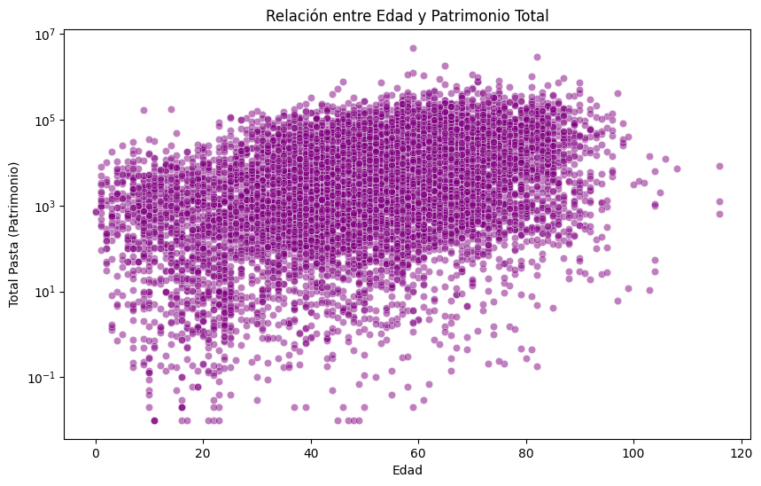

```python
plt.figure(figsize=(10, 6))
sns.scatterplot(x='edad', y='totalpasta', data=df_datasabadell, alpha=0.5, color='purple')
plt.title('Relación entre Edad y Patrimonio Total')
plt.xlabel('Edad')
plt.ylabel('Total Pasta (Patrimonio)')
plt.yscale('log') # Opcional si hay valores muy altos concentrados
plt.show()
```

En el gráfico que se muestra acontinuación se segmentan los clientes en 3 tipos de perfiles segun la edad -Inversión Perfil Pensionado con un total 8034 clientes corresponde al 81.8% del total de cliente, Inversión Perfil Conservador con 1014 clientes equivale al 10.3% e Inversión Perfil Juvenil con 774 clientes (7.9%)

```
==================================================
Gráfico de Barras: Distribución de Clientes por Tipo de Inversión
==================================================
```

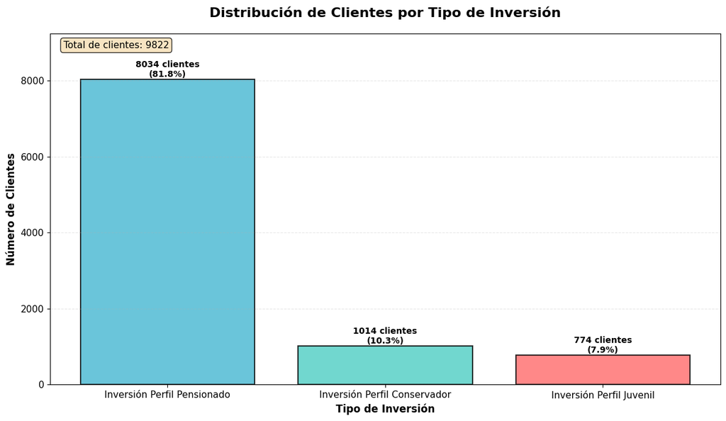

```
Estadísticas detalladas:
• Inversión Perfil Pensionado: 8034 clientes (81.8%)
• Inversión Perfil Conservador: 1014 clientes (10.3%)
• Inversión Perfil Juvenil: 774 clientes (7.9%)

Total general: 9822 clientes
Porcentaje total: 100.0%
```

```python
# Gráfico de barras de la distribución de tipos de inversión
print("\n" + "="*50)
print("Gráfico de Barras: Distribución de Clientes por Tipo de Inversión")
print("="*50)

# Calcular la distribución
distribucion = df_datasabadell['tipo_inversion'].value_counts()

# Crear el gráfico de barras
plt.figure(figsize=(12, 7))

# Crear el gráfico de barras con colores según el tipo de inversión
colores = {
    'Inversión Perfil Juvenil': '#FF6B6B',     # Rojo/naranja para jóvenes
    'Inversión Perfil Conservador': '#4ECDC4',  # Verde/azul para conservadores
    'Inversión Perfil Pensionado': '#45B7D1'    # Azul para pensionados
}

# Obtener colores en el orden correcto
bars = plt.bar(distribucion.index, distribucion.values,
               color=[colores[tipo] for tipo in distribucion.index],
               edgecolor='black', linewidth=1.5, alpha=0.8)

# Añadir etiquetas con los valores exactos
for i, bar in enumerate(bars):
    height = bar.get_height()
    porcentaje = (height / len(df_datasabadell)) * 100
    plt.text(bar.get_x() + bar.get_width()/2., height + 20,
             f'{int(height)} clientes\n({porcentaje:.1f}%)',
             ha='center', va='bottom', fontsize=10, fontweight='bold')

# Personalizar el gráfico
plt.title('Distribución de Clientes por Tipo de Inversión', fontsize=16, fontweight='bold', pad=20)
plt.xlabel('Tipo de Inversión', fontsize=12, fontweight='bold')
plt.ylabel('Número de Clientes', fontsize=12, fontweight='bold')
plt.xticks(fontsize=11, rotation=0)
plt.yticks(fontsize=11)

# Añadir grid
plt.grid(axis='y', alpha=0.3, linestyle='--')

# Ajustar límites del eje Y
plt.ylim(0, max(distribucion.values) * 1.15)

# Añadir anotación con el total de clientes
total_clientes = len(df_datasabadell)
plt.text(0.02, 0.98, f'Total de clientes: {total_clientes}',
         transform=plt.gca().transAxes, fontsize=11,
         verticalalignment='top', bbox=dict(boxstyle='round', facecolor='wheat', alpha=0.8))

# Mostrar el gráfico
plt.tight_layout()
plt.show()

# Mostrar estadísticas adicionales
print("\nEstadísticas detalladas:")
for tipo, count in distribucion.items():
    porcentaje = (count / total_clientes) * 100
    print(f"• {tipo}: {count} clientes ({porcentaje:.1f}%)")

print(f"\nTotal general: {total_clientes} clientes")
print(f"Porcentaje total: {sum([(count / total_clientes) * 100 for count in distribucion.values]):.1f}%")
```

**Provincia del cliente.** El dataset ya trae la provincia real en la columna `prov` (código INE; 99 = residente en el extranjero). A partir de ella se crean `provincia_nombre`, `comunidad_autonoma` y `es_extranjero`, que alimentan la dimensión `dim_geografia` del DWH.

> En la versión anterior se generaba un `id_geografia` **aleatorio** (sin semilla, distinto en cada ejecución). Se elimina porque inventaba un dato que ya existía en la fuente.

```python
# Códigos INE de provincia -> nombre y comunidad autónoma (99 = extranjero)
PROVINCIAS_INE = {
    1: "Araba/Álava", 2: "Albacete", 3: "Alicante/Alacant", 4: "Almería", 5: "Ávila",
    6: "Badajoz", 7: "Illes Balears", 8: "Barcelona", 9: "Burgos", 10: "Cáceres",
    11: "Cádiz", 12: "Castellón/Castelló", 13: "Ciudad Real", 14: "Córdoba", 15: "A Coruña",
    16: "Cuenca", 17: "Girona", 18: "Granada", 19: "Guadalajara", 20: "Gipuzkoa",
    21: "Huelva", 22: "Huesca", 23: "Jaén", 24: "León", 25: "Lleida",
    26: "La Rioja", 27: "Lugo", 28: "Madrid", 29: "Málaga", 30: "Murcia",
    31: "Navarra", 32: "Ourense", 33: "Asturias", 34: "Palencia", 35: "Las Palmas",
    36: "Pontevedra", 37: "Salamanca", 38: "Santa Cruz de Tenerife", 39: "Cantabria", 40: "Segovia",
    41: "Sevilla", 42: "Soria", 43: "Tarragona", 44: "Teruel", 45: "Toledo",
    46: "Valencia/València", 47: "Valladolid", 48: "Bizkaia", 49: "Zamora", 50: "Zaragoza",
    51: "Ceuta", 52: "Melilla", 99: "Extranjero",
}

CCAA_POR_PROVINCIA = {
    **dict.fromkeys([4, 11, 14, 18, 21, 23, 29, 41], "Andalucía"),
    **dict.fromkeys([22, 44, 50], "Aragón"),
    33: "Principado de Asturias", 7: "Illes Balears",
    **dict.fromkeys([35, 38], "Canarias"), 39: "Cantabria",
    **dict.fromkeys([5, 9, 24, 34, 37, 40, 42, 47, 49], "Castilla y León"),
    **dict.fromkeys([2, 13, 16, 19, 45], "Castilla-La Mancha"),
    **dict.fromkeys([8, 17, 25, 43], "Cataluña"),
    **dict.fromkeys([3, 12, 46], "Comunitat Valenciana"),
    **dict.fromkeys([6, 10], "Extremadura"),
    **dict.fromkeys([15, 27, 32, 36], "Galicia"),
    28: "Comunidad de Madrid", 30: "Región de Murcia", 31: "Navarra",
    **dict.fromkeys([1, 20, 48], "País Vasco"), 26: "La Rioja",
    51: "Ceuta", 52: "Melilla", 99: "Extranjero",
}

# Se elimina la columna aleatoria de la versión anterior, si existiera
df_datasabadell = df_datasabadell.drop(columns=['id_geografia'], errors='ignore')

df_datasabadell['provincia_nombre'] = df_datasabadell['prov'].map(PROVINCIAS_INE)
df_datasabadell['comunidad_autonoma'] = df_datasabadell['prov'].map(CCAA_POR_PROVINCIA)
df_datasabadell['es_extranjero'] = (df_datasabadell['prov'] == 99).astype(int)

sin_provincia = df_datasabadell['provincia_nombre'].isna().sum()
print(f"Provincias distintas en la cartera: {df_datasabadell['prov'].nunique()}")
print(f"Clientes con código de provincia no reconocido: {sin_provincia}")
print("\nTop 5 provincias por nº de clientes:")
print(df_datasabadell['provincia_nombre'].value_counts().head(5).to_string())
```

```
Provincias distintas en la cartera: 53
Clientes con código de provincia no reconocido: 0

Top 5 provincias por nº de clientes:
provincia_nombre
Barcelona           2309
Alicante/Alacant    1487
Extranjero           792
Murcia               746
Madrid               724
```

**Fecha de apertura de la cuenta.** Se deriva de la antigüedad real del cliente (`antig`, en **meses**) respecto a la fecha de extracción de la cartera (`FECHA_SNAPSHOT`):

`fecha_apertura = primer día del mes (FECHA_SNAPSHOT − antig meses)`

Con ello se crean también `antiguedad_anios` y `grupo_antiguedad` (tramos en años). Como control de calidad, se comprueba que ningún cliente tenga una cuenta más antigua que su propia edad.

> En la versión anterior `fecha_apertura` se generaba **al azar** dentro de los últimos 1.000 días, lo que contradecía `antig` (hasta 878 meses). Se sustituye por este cálculo determinista. *Supuesto a validar por el equipo:* `antig` está expresada en meses (mediana 120 = 10 años; máximo 878 ≈ 73 años, coherente con clientes de hasta 116 años).

```python
# Fecha de extracción de la cartera: parámetro del proceso ETL (se reutiliza como fecha del snapshot en el DWH)
FECHA_SNAPSHOT = pd.Timestamp('2026-09-11')


def calcular_fecha_apertura(df, fecha_ref=FECHA_SNAPSHOT, col_antig='antig'):
    """Deriva fecha_apertura (día 1 del mes) restando `antig` meses a la fecha de referencia."""
    out = df.copy()
    meses_totales = fecha_ref.year * 12 + (fecha_ref.month - 1) - out[col_antig].astype(int)
    out['fecha_apertura'] = pd.to_datetime(
        pd.DataFrame({'year': meses_totales // 12, 'month': meses_totales % 12 + 1, 'day': 1})
    )
    out['antiguedad_meses'] = out[col_antig].astype(int)
    out['antiguedad_anios'] = (out[col_antig] / 12).round(1)
    out['grupo_antiguedad'] = pd.cut(
        out[col_antig],
        bins=[0, 12, 36, 60, 120, 240, np.inf],
        labels=['≤1 año', '1-3 años', '3-5 años', '5-10 años', '10-20 años', '>20 años'],
        include_lowest=True,
    ).cat.add_categories('Sin dato').fillna('Sin dato').astype(str)
    return out


df_datasabadell = calcular_fecha_apertura(df_datasabadell)

print("📅 FECHA DE APERTURA DERIVADA DE 'antig'")
print("=" * 50)
print(f"   • Fecha más antigua : {df_datasabadell['fecha_apertura'].min():%m/%Y}")
print(f"   • Fecha más reciente: {df_datasabadell['fecha_apertura'].max():%m/%Y}")
print(f"   • Antigüedad media  : {df_datasabadell['antiguedad_anios'].mean():.1f} años "
      f"(mediana {df_datasabadell['antiguedad_anios'].median():.1f})")

print("\n🏷️  GRUPOS POR ANTIGÜEDAD:")
orden = ['≤1 año', '1-3 años', '3-5 años', '5-10 años', '10-20 años', '>20 años']
conteo = df_datasabadell['grupo_antiguedad'].value_counts().reindex(orden, fill_value=0)
for grupo, n in conteo.items():
    print(f"   • {grupo:<11}: {n:5} clientes ({n / len(df_datasabadell) * 100:5.1f}%)")
print(f"   • Sin dato   : {(df_datasabadell['grupo_antiguedad'] == 'Sin dato').sum()}")

# Control de calidad: la cuenta no puede ser más antigua que el cliente (margen de 1 año)
incoherentes = (df_datasabadell['antiguedad_anios'] > df_datasabadell['edad'] + 1).sum()
print(f"\n🔎 Clientes con antigüedad mayor que su edad: {incoherentes}")
```

```
📅 FECHA DE APERTURA DERIVADA DE 'antig'
==================================================
   • Fecha más antigua : 07/1953
   • Fecha más reciente: 08/2026
   • Antigüedad media  : 12.9 años (mediana 10.0)

🏷️  GRUPOS POR ANTIGÜEDAD:
   • ≤1 año     :   735 clientes (  7.5%)
   • 1-3 años   :  1250 clientes ( 12.7%)
   • 3-5 años   :  1101 clientes ( 11.2%)
   • 5-10 años  :  1851 clientes ( 18.8%)
   • 10-20 años :  2653 clientes ( 27.0%)
   • >20 años   :  2232 clientes ( 22.7%)
   • Sin dato   : 0

🔎 Clientes con antigüedad mayor que su edad: 1
```

```python
# Catálogo de los 45 indicadores de producto: código -> (nombre, categoría)
# Es la única definición del catálogo en el notebook: la reutilizan el DWH (dim_producto) y los KPIs.
CATALOGO_PRODUCTOS = {
    # Cuentas
    'ind_cuentaexpansion': ('Cuenta Expansión', 'Cuentas'),
    'ind_cuentaexpansionnegocios': ('Cuenta Expansión Negocios', 'Cuentas'),
    'ind_cuentaexpansionpremium': ('Cuenta Expansión Premium', 'Cuentas'),
    'ind_cuentaexperiencia': ('Cuenta Experiencia', 'Cuentas'),
    'ind_cuentaprimera': ('Cuenta Primera', 'Cuentas'),
    'ind_cuentaproyeccion': ('Cuenta Proyección', 'Cuentas'),
    'ind_altrescc': ('Otras cuentas corrientes', 'Cuentas'),
    # Tarjetas
    'ind_cvautonomos': ('Tarjeta CV Autónomos', 'Tarjetas'),
    'ind_cvdirect': ('Tarjeta CV Direct', 'Tarjetas'),
    'ind_cvhabit': ('Tarjeta CV Habit', 'Tarjetas'),
    'ind_cvjove': ('Tarjeta CV Jove', 'Tarjetas'),
    'ind_cvjunior': ('Tarjeta CV Junior', 'Tarjetas'),
    'ind_cvmas': ('Tarjeta CV Más', 'Tarjetas'),
    'ind_cvprestige': ('Tarjeta CV Prestige', 'Tarjetas'),
    'ind_cvsenior': ('Tarjeta CV Senior', 'Tarjetas'),
    # Inversión y ahorro
    'ind_estalinv': ('Estalvi Inversión', 'Inversion_Ahorro'),
    'ind_estalvi': ('Estalvi (Ahorro)', 'Inversion_Ahorro'),
    'ind_asvidaestgarcol': ('Seguro Vida Ahorro Garantizado Colectivo', 'Inversion_Ahorro'),
    'ind_asvidaestulinkc': ('Seguro Vida Ahorro Unit Linked Colectivo', 'Inversion_Ahorro'),
    'ind_bonsestruc': ('Bonos estructurados', 'Inversion_Ahorro'),
    'ind_cialp': ('CIALP (Cuenta Individual Ahorro L/P)', 'Inversion_Ahorro'),
    'ind_diposit': ('Depósitos', 'Inversion_Ahorro'),
    'ind_fi': ('Fondos de inversión', 'Inversion_Ahorro'),
    'ind_fialtent': ('Fondos de inversión alternativos', 'Inversion_Ahorro'),
    'ind_gcfisbp': ('Gestión de carteras', 'Inversion_Ahorro'),
    'ind_gransel': ('Gran Selección', 'Inversion_Ahorro'),
    'ind_pp': ('Planes de pensiones', 'Inversion_Ahorro'),
    'ind_ppassoci': ('Planes de pensiones asociados', 'Inversion_Ahorro'),
    'ind_ppemp': ('Planes de pensiones de empleo', 'Inversion_Ahorro'),
    'ind_pprest': ('Planes de previsión (prestaciones)', 'Inversion_Ahorro'),
    'ind_rentvitindiv': ('Renta vitalicia individual', 'Inversion_Ahorro'),
    'ind_renttempcol': ('Renta temporal colectiva', 'Inversion_Ahorro'),
    'ind_renttempind': ('Renta temporal individual', 'Inversion_Ahorro'),
    'ind_restorvrf': ('Resto renta variable / renta fija', 'Inversion_Ahorro'),
    'ind_rfixaval': ('Renta fija', 'Inversion_Ahorro'),
    'ind_vrdafix': ('Valores de renta fija', 'Inversion_Ahorro'),
    # Financiación
    'ind_credf': ('Crédito', 'Financiacion'),
    'ind_credv': ('Crédito vivienda', 'Financiacion'),
    'ind_hipfix': ('Hipoteca tipo fijo', 'Financiacion'),
    'ind_hipmixt': ('Hipoteca tipo mixto', 'Financiacion'),
    'ind_hipoteca': ('Hipoteca', 'Financiacion'),
    'ind_hipvar': ('Hipoteca tipo variable', 'Financiacion'),
    'ind_promotor': ('Préstamo promotor', 'Financiacion'),
    'ind_rentvehic': ('Renting de vehículo', 'Financiacion'),
    # Otros
    'ind_varispassiu': ('Otros productos de pasivo', 'Otros'),
}
IND_COLS = list(CATALOGO_PRODUCTOS)

# 'ind_estalinv' es un indicador RESUMEN de la fuente: vale 1 exactamente cuando el cliente tiene algún
# otro producto de ahorro/inversión. Se excluye del conteo para no contar dos veces el mismo producto.
INDICADORES_RESUMEN = ['ind_estalinv']
PRODUCTOS_INVERSION = [c for c, (_, cat) in CATALOGO_PRODUCTOS.items()
                       if cat == 'Inversion_Ahorro' and c not in INDICADORES_RESUMEN]

faltan = [c for c in IND_COLS if c not in df_datasabadell.columns]
assert not faltan, f"Faltan indicadores en el dataset: {faltan}"
print(f"Indicadores de producto: {len(IND_COLS)} | de inversión/ahorro: {len(PRODUCTOS_INVERSION)}")


def calcular_segmento_edad(edad):
    """Segmento de edad en 3 categorías: Joven (≤18), Adulto (19-45), Senior (>45)."""
    if pd.isna(edad):
        return 'Desconocido'
    if edad <= 18:
        return 'Joven'
    if edad <= 45:
        return 'Adulto'
    return 'Senior'


df_datasabadell['segmento_edad'] = df_datasabadell['edad'].apply(calcular_segmento_edad)
df_datasabadell['total_productos_activos'] = df_datasabadell[IND_COLS].sum(axis=1).astype(int)
df_datasabadell['num_prod_inversion'] = df_datasabadell[PRODUCTOS_INVERSION].sum(axis=1).astype(int)
df_datasabadell['tiene_inversion'] = (df_datasabadell['num_prod_inversion'] > 0).astype(int)

# Control de coherencia: tiene_inversion debe coincidir con el indicador resumen de la fuente
assert (df_datasabadell['tiene_inversion'] == df_datasabadell['ind_estalinv']).all(), \
    "tiene_inversion no coincide con ind_estalinv"
print("✔ tiene_inversion coincide al 100 % con el indicador resumen ind_estalinv de la fuente")

# Guardar el dataset actualizado (se entrega junto al notebook)
output_excel_path = Path.cwd() / "datasabadell_actualizado_con_segmentos.xlsx"
df_datasabadell.to_excel(output_excel_path, index=False)
print(f"\n✅ Dataset actualizado guardado en: {output_excel_path}")
print(f"   - Registros: {df_datasabadell.shape[0]} | Columnas: {df_datasabadell.shape[1]}")

print("\n📊 RESUMEN DE LAS NUEVAS COLUMNAS")
print(f"   • total_productos_activos: media {df_datasabadell['total_productos_activos'].mean():.2f} "
      f"(mín {df_datasabadell['total_productos_activos'].min()}, máx {df_datasabadell['total_productos_activos'].max()})")
print(f"   • num_prod_inversion     : media {df_datasabadell['num_prod_inversion'].mean():.2f} "
      f"(máx {df_datasabadell['num_prod_inversion'].max()})")
con_inv = df_datasabadell['tiene_inversion'].sum()
print(f"   • tiene_inversion        : {con_inv} clientes CON inversión ({con_inv / len(df_datasabadell) * 100:.1f}%), "
      f"{len(df_datasabadell) - con_inv} SIN inversión")
print("\n   • segmento_edad:")
print(df_datasabadell['segmento_edad'].value_counts().to_string())
```

```
Indicadores de producto: 45 | de inversión/ahorro: 20
✔ tiene_inversion coincide al 100 % con el indicador resumen ind_estalinv de la fuente

✅ Dataset actualizado guardado en: c:\Users\jmendozarojas\OneDrive - Getronics\Escritorio\INESDI\TFM\Entrega 2\datasabadell_actualizado_con_segmentos.xlsx
   - Registros: 9822 | Columnas: 96

📊 RESUMEN DE LAS NUEVAS COLUMNAS
   • total_productos_activos: media 2.16 (mín 0, máx 11)
   • num_prod_inversion     : media 0.78 (máx 9)
   • tiene_inversion        : 3261 clientes CON inversión (33.2%), 6561 SIN inversión

   • segmento_edad:
segmento_edad
Senior    5627
Adulto    3421
Joven      774
```

**Tenencia de productos de inversión por perfil de cliente.** El gráfico se calcula directamente con `pd.crosstab` sobre `tipo_inversion` y `num_prod_inversion` (sin valores fijados a mano). Solo cuentan los productos de la categoría Inversion_Ahorro.

**Resultado:**

- **Pensionado**: 36,1 % de sus clientes tiene al menos un producto de inversión (2.899 de 8.034).
- **Juvenil**: 25,8 % (200 de 774).
- **Conservador** (19–30 años): **16,0 %** (162 de 1.014). Es el perfil que **menos invierte**, tanto en porcentaje como en número de productos, lo que refuerza la oportunidad del producto de inversión para la primera vivienda.

> La versión anterior de este gráfico usaba porcentajes fijados a mano y concluía que el perfil Juvenil era el que menos invertía. Con los datos reales, el perfil con menor tenencia es el Conservador.

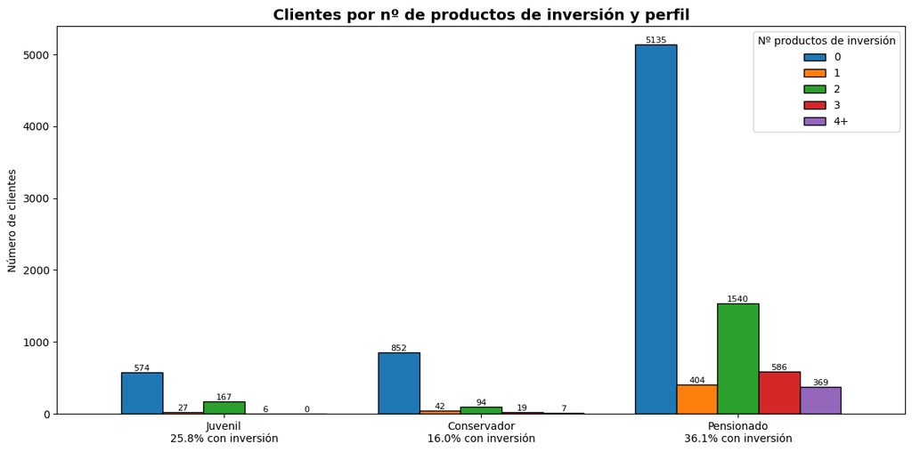

| num_prod_inversion tipo_inversion | 0 | 1 | 2 | 3 | 4+ | TOTAL | % con inversión |
| --- | --- | --- | --- | --- | --- | --- | --- |
| Inversión Perfil Juvenil | 574 | 27 | 167 | 6 | 0 | 774 | 25.8 |
| Inversión Perfil Conservador | 852 | 42 | 94 | 19 | 7 | 1014 | 16.0 |
| Inversión Perfil Pensionado | 5135 | 404 | 1540 | 586 | 369 | 8034 | 36.1 |

```python
# Tabla cruzada real: perfil de inversión x nº de productos de inversión (0, 1, 2, 3, 4+)
orden_perfiles = ['Inversión Perfil Juvenil', 'Inversión Perfil Conservador', 'Inversión Perfil Pensionado']
tramos = pd.cut(df_datasabadell['num_prod_inversion'], bins=[-1, 0, 1, 2, 3, np.inf],
                labels=['0', '1', '2', '3', '4+'])
tabla_inv = (pd.crosstab(df_datasabadell['tipo_inversion'], tramos)
             .reindex(index=orden_perfiles, columns=['0', '1', '2', '3', '4+'], fill_value=0))
tabla_inv.columns = tabla_inv.columns.astype(str)
tabla_inv['TOTAL'] = tabla_inv.sum(axis=1)
tabla_inv['% con inversión'] = ((1 - tabla_inv['0'] / tabla_inv['TOTAL']) * 100).round(1)

fig, ax = plt.subplots(figsize=(12, 6))
tabla_inv[['0', '1', '2', '3', '4+']].plot(kind='bar', ax=ax, edgecolor='black', width=0.8)
ax.set_title('Clientes por nº de productos de inversión y perfil', fontsize=14, fontweight='bold')
ax.set_xlabel('')
ax.set_ylabel('Número de clientes')
ax.set_xticklabels([f"{p.replace('Inversión Perfil ', '')}\n{pct}% con inversión"
                    for p, pct in zip(tabla_inv.index, tabla_inv['% con inversión'])], rotation=0)
ax.legend(title='Nº productos de inversión')
for cont in ax.containers:
    ax.bar_label(cont, fmt='%d', fontsize=8)
plt.tight_layout()
plt.show()

tabla_inv
```

# 4. INGESTA DE LOS DATOS EN MySQL

El dataset limpio (`df_datasabadell`, 9.822 clientes) se prepara y se inserta en MySQL desde este notebook.

| Paso | Qué se hace | Resultado |
| --- | --- | --- |
| 4.1 Conexión | `SQLAlchemy` + `pymysql`; crea la base de datos si no existe | `engine` |
| 4.2 Preparación | `gastos_tot` de texto moneda a numérico, tipos compatibles con MySQL, validación de claves | `df_stg` |
| 4.3 Carga | Inserción en la tabla de staging y clave primaria `id_cliente` | `stg_clientes_original` |
| 4.4 Verificación | Recuento de filas en MySQL frente al DataFrame | 9.822 = 9.822 |

**Requisitos:** `pip install sqlalchemy pymysql` y un servidor MySQL en ejecución. Las credenciales se leen de variables de entorno (`MYSQL_USER`, `MYSQL_PASSWORD`, `MYSQL_HOST`, `MYSQL_PORT`, `MYSQL_DB`); si no hay contraseña definida, el notebook la pide por pantalla.

```python
# [CELDA_CONEXION_MYSQL]
# 4.1 Conexión a MySQL
import os
import getpass
from sqlalchemy import create_engine, text
from sqlalchemy.engine import URL

# === DICCIONARIO CORREGIDO ===
MYSQL_CONFIG = {
    'usuario':    os.getenv('MYSQL_USER', 'root'),
    'password':   os.getenv('MYSQL_PASSWORD') or getpass.getpass('Contraseña de MySQL: '),
    'host':       os.getenv('MYSQL_HOST', 'localhost'),
    'puerto':     int(os.getenv('MYSQL_PORT', '3306')),
    'base_datos': os.getenv('MYSQL_DB', 'bancosabadell_dw'),
}

# === FUNCIÓN url_mysql CORREGIDA ===
def url_mysql(con_base_datos=True):
    # VERIFICACIÓN DE SEGURIDAD
    claves_requeridas = ['usuario', 'password', 'host', 'puerto', 'base_datos']
    for clave in claves_requeridas:
        if clave not in MYSQL_CONFIG:
            raise KeyError(f"Clave '{clave}' no encontrada en MYSQL_CONFIG")

    return URL.create(
        'mysql+pymysql',
        username=MYSQL_CONFIG['usuario'],        # ← CORREGIDO
        password=MYSQL_CONFIG['password'],      # ← CORREGIDO
        host=MYSQL_CONFIG['host'],
        port=MYSQL_CONFIG['puerto'],
        database=MYSQL_CONFIG['base_datos'] if con_base_datos else None,
        query={'charset': 'utf8mb4'},
    )

# === PRUEBA DE CONEXIÓN ===
print("🔧 Probando conexión...")
try:
    # Probar que la función funciona
    url_prueba = url_mysql(con_base_datos=False)
    print(f"✅ url_mysql() funciona correctamente")

    # Crear engine_servidor
    engine_servidor = create_engine(url_mysql(con_base_datos=False))
    print(f"✅ engine_servidor creado exitosamente")

    # Crear la base de datos si no existe
    with engine_servidor.begin() as con:
        con.execute(text(
            f"CREATE DATABASE IF NOT EXISTS `{MYSQL_CONFIG['base_datos']}` "
            "CHARACTER SET utf8mb4 COLLATE utf8mb4_spanish_ci"
        ))
    engine_servidor.dispose()
    print(f"✅ Base de datos '{MYSQL_CONFIG['base_datos']}' verificada/creada")

    # Crear engine principal
    engine = create_engine(url_mysql(), pool_pre_ping=True)

    # Verificar conexión
    import pandas as pd
    pd.read_sql(text("SELECT 1 AS prueba"), engine)   # comprueba que la conexión responde
    print(f"✅ Conectado a MySQL | base de datos: {MYSQL_CONFIG['base_datos']}")

except KeyError as e:
    print(f"❌ ERROR DE CLAVES: {e}")
    print("   Verifica que MYSQL_CONFIG tenga las claves correctas:")
    print(f"   Claves disponibles: {list(MYSQL_CONFIG.keys())}")
    raise
except Exception as e:
    print(f"❌ ERROR GENERAL: {e}")
    print("   Posibles causas:")
    print("   1. MySQL no está corriendo en localhost:3306")
    print("   2. Usuario/contraseña incorrectos")
    print("   3. No tienes permisos para crear bases de datos")
    raise
```

```
🔧 Probando conexión...
✅ url_mysql() funciona correctamente
✅ engine_servidor creado exitosamente
✅ Base de datos 'bancosabadell_dw' verificada/creada
✅ Conectado a MySQL | base de datos: bancosabadell_dw
```

### 4.2 Preparación del dataset para la ingesta

Transformaciones de limpieza necesarias para que los datos entren en columnas tipadas de MySQL:

1. `gastos_tot`: de texto con formato moneda (`" € 1,278.64"`, `" € - "`) a número; el guion equivale a 0 €. Dos celdas del Excel de origen contienen `##########` (desbordamiento de celda: el importe no se conserva) y se cargan como nulo.
2. Columnas categóricas y de fecha convertidas a tipos nativos (texto y `datetime`).
3. Indicadores `ind_*` y flags garantizados como enteros 0/1.
4. Validaciones: `id_cliente` único y sin nulos, sin códigos de provincia desconocidos.

```python
def convertir_moneda(serie):
    """' €  1,278.64' -> 1278.64 ; ' €  -  ' -> 0.0"""
    limpio = (serie.astype(str)
                   .str.replace('€', '', regex=False)
                   .str.replace(',', '', regex=False)
                   .str.strip())
    limpio = limpio.replace({'-': '0', '': np.nan, 'nan': np.nan})
    # '##########' = desbordamiento de celda en el Excel de origen: el importe se perdió -> nulo
    limpio = limpio.mask(limpio.str.fullmatch(r'#+', na=False))
    return pd.to_numeric(limpio, errors='coerce')


def preparar_para_mysql(df):
    out = df.copy()

    # 1) gastos_tot: texto moneda -> numérico
    if not pd.api.types.is_numeric_dtype(out['gastos_tot']):
        desbordados = out['gastos_tot'].astype(str).str.strip().str.fullmatch(r'#+').sum()
        out['gastos_tot'] = convertir_moneda(out['gastos_tot'])
        print(f"gastos_tot: {desbordados} valores '##########' en el Excel de origen se cargan como nulo")

    # 2) tipos nativos
    for col in out.select_dtypes(include='category').columns:
        out[col] = out[col].astype(str)
    out['fecha_apertura'] = pd.to_datetime(out['fecha_apertura'])

    # 3) indicadores y flags como enteros 0/1
    flags = IND_COLS + ['tiene_inversion', 'renta_imputada', 'es_extranjero', 'residente', 'tpv']
    out[flags] = out[flags].fillna(0).astype(int)

    # 4) validaciones
    assert out['id_cliente'].notna().all(), "Hay id_cliente nulos"
    assert out['id_cliente'].is_unique, "Hay id_cliente duplicados"
    assert out['provincia_nombre'].notna().all(), "Hay códigos de provincia no reconocidos"
    assert out['gastos_tot'].isna().sum() <= 5, "gastos_tot tiene demasiados valores no convertibles"
    return out


df_stg = preparar_para_mysql(df_datasabadell)
print(f"gastos_tot convertido: media {df_stg['gastos_tot'].mean():,.2f} € | "
      f"clientes con gasto 0: {(df_stg['gastos_tot'] == 0).sum()}")
print(f"Dataset listo para ingesta: {df_stg.shape[0]} filas x {df_stg.shape[1]} columnas")
```

```
gastos_tot: 2 valores '##########' en el Excel de origen se cargan como nulo
gastos_tot convertido: media 251.95 € | clientes con gasto 0: 6522
Dataset listo para ingesta: 9822 filas x 96 columnas
```

```python
# 4.3 Carga en la tabla de staging (copia fiel del dataset limpio) + clave primaria
TABLA_STAGING = 'stg_clientes_original'

df_stg.to_sql(TABLA_STAGING, engine, if_exists='replace', index=False, chunksize=1000, method='multi')
with engine.begin() as con:
    con.execute(text(f"ALTER TABLE {TABLA_STAGING} ADD PRIMARY KEY (id_cliente)"))

# 4.4 Verificación de la ingesta
control = pd.read_sql(text(
    f"SELECT COUNT(*) AS filas, COUNT(DISTINCT id_cliente) AS clientes_unicos, "
    f"ROUND(SUM(totalpasta), 2) AS patrimonio_total FROM {TABLA_STAGING}"
), engine)
print(control.to_string(index=False))
assert control.loc[0, 'filas'] == len(df_stg), "El nº de filas en MySQL no coincide con el DataFrame"
assert abs(control.loc[0, 'patrimonio_total'] - df_stg['totalpasta'].sum()) < 1, "El patrimonio total no cuadra"
print(f"\n✅ Ingesta verificada: {len(df_stg)} clientes en {TABLA_STAGING}")
```

```
 filas  clientes_unicos  patrimonio_total
  9822             9822      231076038.57

✅ Ingesta verificada: 9822 clientes en stg_clientes_original
```

# 5. TRANSFORMACIÓN Y CARGA: MODELO DEL DATAWAREHOUSE

El proceso **extrae** los clientes de la tabla de staging en MySQL, los **transforma** con pandas y **carga** el resultado en tablas nuevas del DWH.

**Transformaciones implementadas**

| # | Transformación | Tipo | Tabla destino |
| --- | --- | --- | --- |
| T1 | Decodificación de `nivren` a `nivel_renta` (Bajo … Alto) | Mapeo / enriquecimiento | `dim_cliente` |
| T2 | Provincia → nombre, comunidad autónoma y flag extranjero | Enriquecimiento con tabla maestra | `dim_geografia` |
| T3 | Catálogo de 45 productos con nombre y categoría | Tabla maestra | `dim_producto` |
| T4 | Calendario (año, trimestre, mes, día de la semana, fin de semana) | Derivación de fechas | `dim_tiempo` |
| T5 | Claves subrogadas (`*_sk`) y resolución de claves foráneas | Integración (joins) | todas |
| T6 | Renombrado de columnas técnicas a nombres de negocio | Estandarización | `fact_cliente_snapshot` |
| T7 | `deuda_total`, `ratio_endeudamiento` y `nivel_riesgo_endeudamiento` | Cálculo | `fact_cliente_snapshot` |
| T8 | Flag `tiene_datos_familia` para los 4.890 clientes sin datos familiares | Calidad de datos | `dim_cliente` |
| T9 | Pivotado de 45 columnas `ind_*` a filas cliente-producto (*melt*) | Reestructuración | `fact_producto_cliente` |
| T10 | Agregados por segmento, nivel de renta, provincia, producto y nº de productos | Agregación (`groupby`) | `agg_*` |
| T11 | Ranking de los 100 clientes con más patrimonio y su peso en la cartera | Ranking / ventana | `agg_top_clientes_patrimonio` |

**Modelo:** dos tablas de hechos (`fact_cliente_snapshot`, `fact_producto_cliente`) que comparten las dimensiones `dim_cliente` y `dim_tiempo`, con `dim_segmento` y `dim_geografia` colgando de `dim_cliente`. Sobre ellas se construyen 6 tablas agregadas para la explotación y 3 tablas de KPIs (sección 6).

```python
# 5.1 Extracción desde MySQL (staging)
df_base = pd.read_sql(text(f"SELECT * FROM {TABLA_STAGING}"), engine)
df_base['fecha_apertura'] = pd.to_datetime(df_base['fecha_apertura'])
print(f"Extraídos {len(df_base)} clientes de {TABLA_STAGING}")
```

```
Extraídos 9822 clientes de stg_clientes_original
```